# Reproducible Research: Peer Assessment 1

Diego Miranda-Saavedra

2/12/2018

This assignment makes use of data from a personal activity monitoring device. This device collects data at 5 minute intervals through out the day. The data consists of two months of data from an anonymous individual collected during the months of October and November, 2012 and include the number of steps taken in 5 minute intervals each day.

## (1) Loading and preprocessing the data

```r
d <- read.csv("/Users/diego/Documents/MOOCs/ReproducibleResearch/Project1/activity.csv", header=TRUE)

head(d)
```

```
##   steps       date interval
## 1    NA 2012-10-01        0
## 2    NA 2012-10-01        5
## 3    NA 2012-10-01       10
## 4    NA 2012-10-01       15
## 5    NA 2012-10-01       20
## 6    NA 2012-10-01       25
```

```r
dim(d)
```

```
## [1] 17568     3
```

```r
summary(d)
```

```
##      steps                date          interval
##  Min.   :  0.00   2012-10-01:  288   Min.   :   0.0
##  1st Qu.:  0.00   2012-10-02:  288   1st Qu.: 588.8
##  Median :  0.00   2012-10-03:  288   Median :1177.5
##  Mean   : 37.38   2012-10-04:  288   Mean   :1177.5
##  3rd Qu.: 12.00   2012-10-05:  288   3rd Qu.:1766.2
##  Max.   :806.00   2012-10-06:  288   Max.   :2355.0
##  NA's   :2304     (Other)   :15840
```

```r
length(which(is.na(d$steps)))
```

```
## [1] 2304
```

## (2) What is mean total number of steps taken per day?

(2.1) Calculate the total number of steps taken per day.

For this I understand that I need to calculate the total number of steps for each day (by adding up all the steps for all intervals for any one day).

```r
d_agg <- aggregate(d$steps, by=list(Date=d$date), FUN=sum, na.rm=TRUE)

totalSteps <- sum(d_agg$x)
totalSteps
```

```
## [1] 570608
```

The total number of steps across all 61 days is 570608.

(2.2) Make a histogram of the total number of steps taken each day. Here I understand that I have to plot the total number of steps for each day, as calculate in the previous step.

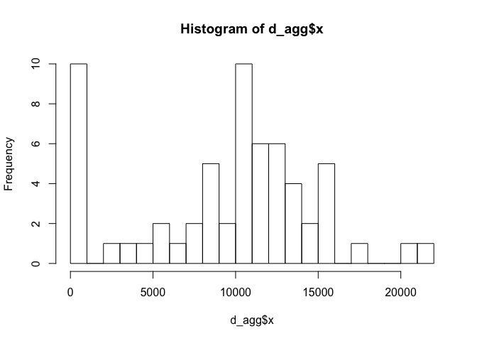

```r
hist(d_agg$x, breaks=30)
```

(2.3) Calculate and report the mean and median of the total number of steps taken per day

```r
mean(d_agg$x, na.rm=TRUE)
```

```
## [1] 9354.23
```

```r
median(d_agg$x, na.rm=TRUE)
```

```
## [1] 10395
```

Average number of steps per day: 9354.23 Median number of steps per day: 10395

## (3) What is the average daily activity pattern?

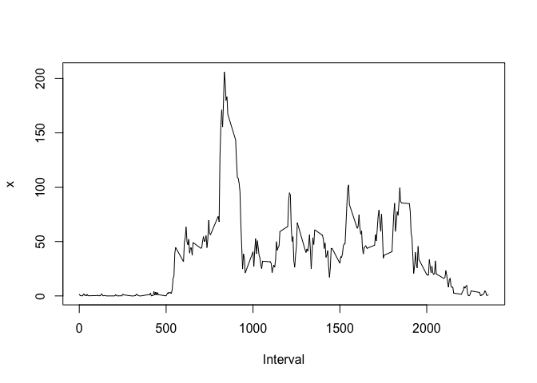

```r
d_agg_interval <- aggregate(d$steps, by=list(Interval=d$interval), FUN=mean, na.rm=TRUE)

plot (d_agg_interval, type="l")
```

```r
d_agg_interval_ordered <- d_agg_interval[order(d_agg_interval$x),]

tail (d_agg_interval_ordered)
```

```
##     Interval        x
## 101      820 171.1509
## 103      830 177.3019
## 106      845 179.5660
## 107      850 183.3962
## 105      840 195.9245
## 104      835 206.1698
```

Interval 835 contains on average the maximum number of steps (206.1698).

## (4) Imputing missing values

(4.1) Calculate and report the total number of missing values in the dataset.

```r
length(which(is.na(d$steps)))
```

```
## [1] 2304
```

(4.2, 4.3) Devise a strategy for filling in all of the missing values in the dataset. The strategy does not need to be sophisticated. For example, you could use the mean/median for that day, or the mean for that 5-minute interval, etc.

If you want to substitute the NA values from the original object (d), every time you encounter an ‘NA’ in the original dataset you have to retrieve the average value for that interval from object ‘d_agg_interval’ and put it in place of the ‘NA’.

Results are stored into a new data frame (d.imput).

```r
d.imput <- data.frame()

for (i in 1:nrow(d)) {
  row <- d[i,]
  if (is.na(row$steps)==TRUE) row$steps <- d_agg_interval$x[match(row$interval,d_agg_interval$Interval)]
  d.imput <- rbind (d.imput,row)
}
```

(4.4) Make a histogram of the total number of steps taken each day and calculate and report the mean and median total number of steps taken per day. Do these values differ from the estimates from the first part of the assignment? What is the impact of imputing missing data on the estimates of the total daily number of steps?

```r
d.imput_agg <- aggregate (d.imput$steps, by=list(Date=d.imput$date), FUN=sum)

mean(d.imput_agg$x)
```

```
## [1] 10766.19
```

```r
median(d.imput_agg$x)
```

```
## [1] 10766.19
```

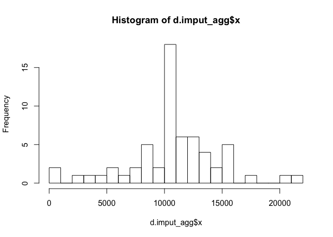

```r
hist(d.imput_agg$x, breaks=30)
```

## (5) Are there differences in activity patterns between weekdays and weekends?

(5.1) Create a new factor variable in the dataset with two levels – “weekday” and “weekend” indicating whether a given date is a weekday or weekend day.

I did not use the weekdays() function that was recommended because the value returned is the day of the week, which I would then have to parse to find out whether a day is part of the weekend (i.e. starting with letter ‘S’). I found the function isWeekend() much more convenient. We will have to install the corresponding package, though.

```r
install.packages('timeDate', repos='http://cran.us.r-project.org')
library(timeDate)
weekendvec <- isWeekend(d.imput$date)
d.imput[,"weekend"]<-weekendvec

head(d.imput)
```

```
##       steps       date interval weekend
## 1 1.7169811 2012-10-01        0   FALSE
## 2 0.3396226 2012-10-01        5   FALSE
## 3 0.1320755 2012-10-01       10   FALSE
## 4 0.1509434 2012-10-01       15   FALSE
## 5 0.0754717 2012-10-01       20   FALSE
## 6 2.0943396 2012-10-01       25   FALSE
```

(5.2) Make a panel plot containing a time series plot (i.e. ) of the 5-minute interval (x-axis) and the average number of steps taken, averaged across all weekday days or weekend days (y-axis). See the README file in the GitHub repository to see an example of what this plot should look like using simulated data.

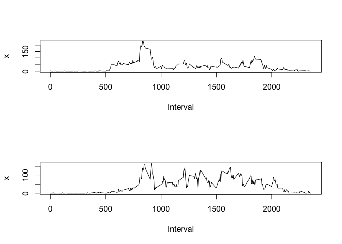

```r
d.imput.weekdays <- d.imput [which(d.imput$weekend=='FALSE'),]
d.imput.weekend <- d.imput [which(d.imput$weekend=='TRUE'),]

par(mfrow=c(2,1))
d.imput.weekdays_interval <- aggregate(d.imput.weekdays$steps, by=list(Interval=d.imput.weekdays$interval), FUN=mean)
plot (d.imput.weekdays_interval, type="l")

d.imput.weekend_interval <- aggregate(d.imput.weekend$steps, by=list(Interval=d.imput.weekend$interval), FUN=mean)
plot (d.imput.weekend_interval, type="l")
```